# Metaketa I - Chapter 11 - Replication

# Figure 11.4: Bayesian Meta-Analysis: Turnout

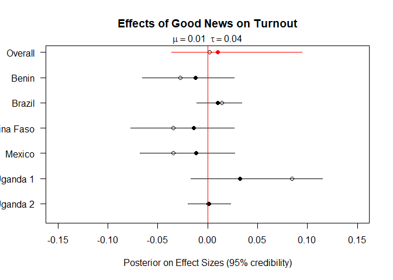

Bayesian Meta-analysis: Turnout. The solid dots and lines show the estimates from the Bayesian model; the top row shows the overall meta-estimate of *Î¼* and *Ï„*. The white dots show the original frequentist estimates: in many cases shrinkage can be observed, especially in cases that have effects that are more imprecisely estimated.

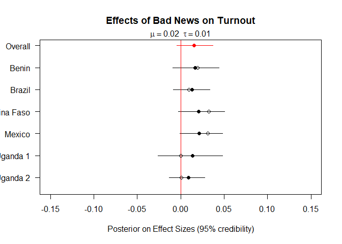

Bayesian Meta-analysis: Turnout. The solid dots and lines show the estimates from the Bayesian model; the top row shows the overall meta-estimate of *Î¼* and *Ï„*. The white dots show the original frequentist estimates: in many cases shrinkage can be observed, especially in cases that have effects that are more imprecisely estimated.

# Figures 11.5 and 11.6: Specification Distribution: Treatment effects under different specification choices

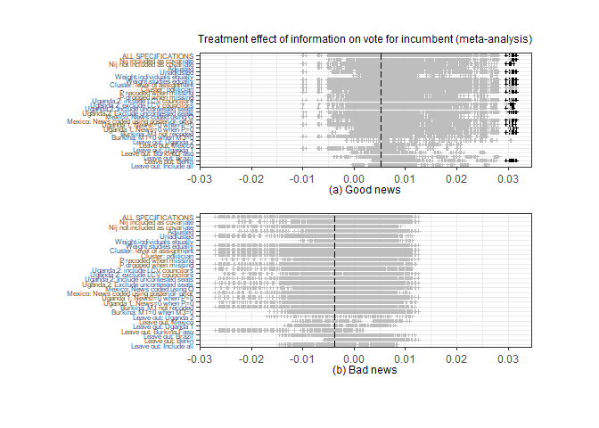

Specification Distribution: Vote for Incumbent. Distribution of average treatment effects on vote for incumbent for a given specification choice, varying all other choices. Darkened vertical lines show estimates for which *p* < 0.05. The dashed vertical line indicates average treatment effect reported in Table 11.1.

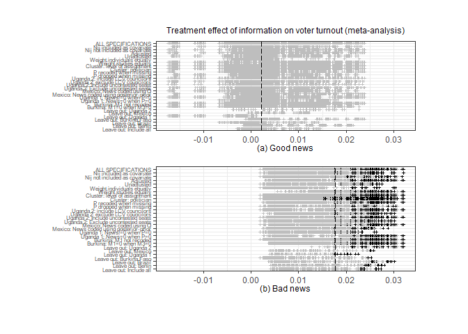

Specification Distribution: Turnout. Distribution of average treatment effects on voter turnout for a given specification choice, varying all other choices. Darkened vertical lines show estimates for which *p* < 0.05. The dashed vertical line indicates average treatment effect reported in Table 11.1.

# Figure 11.7: Power analysis of minimal detectable effects

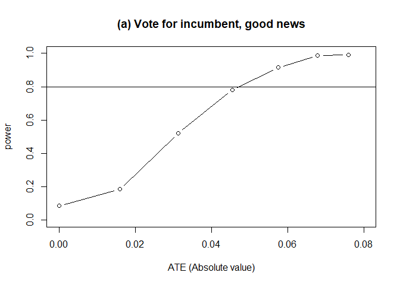

Minimal detectable effects: Power analysis of minimal detectable effects, computed using Monte Carlo simulation. The horizontal axis varies the conjectured average treatment effect, while the vertical axis shows statistical power: the probability of rejecting the null hypothesis at *Î±* = 0.05.

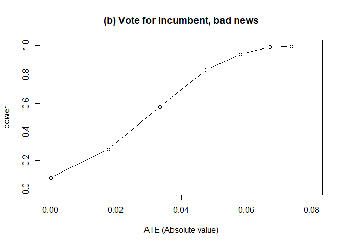

Minimal detectable effects: Power analysis of minimal detectable effects, computed using Monte Carlo simulation. The horizontal axis varies the conjectured average treatment effect, while the vertical axis shows statistical power: the probability of rejecting the null hypothesis at *Î±* = 0.05.

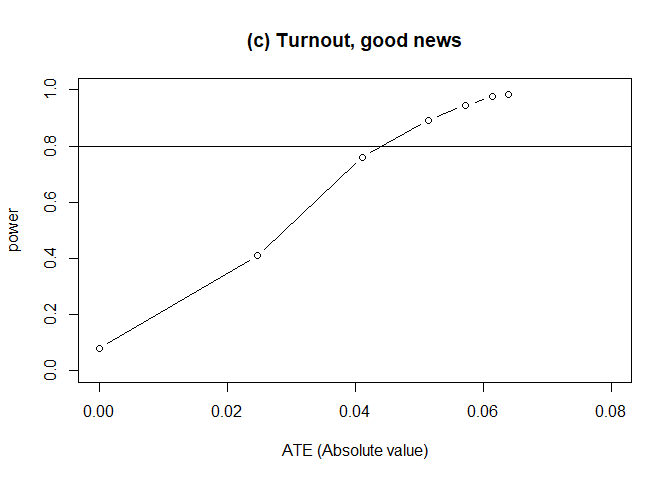

Minimal detectable effects: Power analysis of minimal detectable effects, computed using Monte Carlo simulation. The horizontal axis varies the conjectured average treatment effect, while the vertical axis shows statistical power: the probability of rejecting the null hypothesis at *Î±* = 0.05.

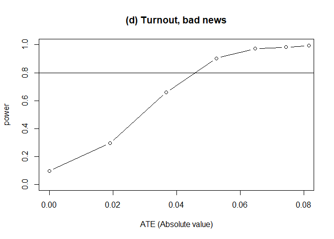

Minimal detectable effects: Power analysis of minimal detectable effects, computed using Monte Carlo simulation. The horizontal axis varies the conjectured average treatment effect, while the vertical axis shows statistical power: the probability of rejecting the null hypothesis at *Î±* = 0.05.

# Table 11.3: Manipulation check (effect of treatment on correct recollection)

```r
# source("1d_prep_manipulation.R")
madat_m30 <- madat %>% subset(!is.na(correct))

m30mc1_o <- estimates(dat = madat_m30, depvar = "correct", exclude_councilors = TRUE)
m30mc2_o <- estimates(dat = madat_m30, depvar = "correct", weights = FALSE, country = "ben")
m30mc3_o <- estimates(dat = madat_m30, depvar = "correct", country = "brz")
m30mc4_o <- estimates(dat = madat_m30, depvar = "correct", weights = FALSE, country = "mex")
m30mc5_o <- estimates(dat = madat_m30, depvar = "correct", weights = FALSE, country = "ug1")
m30mc6_o <- estimates(dat = madat_m30, depvar = "correct", weights = TRUE, country = "ug2", exclude_councilors = TRUE)
```

Manipulation check: Effect of treatment on correct recollection, pooling good and bad news
$$unregistered analysis$$

Correct Recollection

Overall

Benin

Brazil

Mexico

Uganda 1

Uganda 2

Treatment

0.072***

0.050

0.038

0.149***

0.119***

-0.0001

(0.015)

(0.059)

(0.021)

(0.015)

(0.035)

(0.008)

Covariates

No

No

No

No

No

No

Observations

16,173

897

1,677

2,089

750

10,760

R<sup>2</sup>

0.320

0.276

0.378

0.137

0.035

0.205

# Table 11.4: Manipulation check (difference between posteriors and priors)

```r
madat_m30b <- madat %>% subset(!is.na(post.prior.diff))
madat_m30b$post.prior.diff <- abs(madat_m30b$post.prior.diff)

# overall news
m30mc1_g <- estimates(dat = madat_m30b, good = NULL, depvar = "post.prior.diff", exclude_councilors = TRUE)
m30mc2_g <- estimates(dat = madat_m30b, good = NULL, depvar = "post.prior.diff", weights = FALSE, country = "ben")
m30mc3_g <- estimates(dat = madat_m30b, good = NULL, depvar = "post.prior.diff", country = "brz")
# m30mc5_g <- estimates(dat = madat_m30b, good = TRUE, depvar = "post.prior.diff", weights = FALSE, country = "ug1")
m30mc6_g <- estimates(dat = madat_m30b, good = NULL, depvar = "post.prior.diff", weights = TRUE, country = "ug2", exclude_councilors = TRUE)
```

Manipulation check: Absolute difference between posterior and prior beliefs for pooled good and bad news
$$unregistered analysis$$

Absolute difference between posterior and prior beliefs

Overall

Benin

Brazil

Uganda 2

Treatment

0.006

0.063

-0.003

-0.023

(0.025)

(0.089)

(0.022)

(0.023)

Covariates

No

No

No

No

Observations

12,704

389

1,677

10,638

R<sup>2</sup>

0.241

0.176

0.358

0.111

# Table 11.5: Effect of information on perception of importance of politician effort and honesty

```r
# M5 ----
m5gc1 <- results(dat = madat_iter, good = TRUE, depvar = "m5", exclude_councilors = TRUE, sims = n_iter,
                 ri_p = ri_action, file_rite_obj = "data/temp/ri_m5pool_g_unadj.Rda")
## good news

m5bc1 <- results(dat = madat_iter, good = FALSE, depvar = "m5", exclude_councilors = TRUE, sims = n_iter,
                   ri_p = ri_action, file_rite_obj = "data/temp/ri_m5pool_b_unadj.Rda") ## bad news
# M6 ----
m6gc1 <- results(dat = madat_iter, good = TRUE, depvar = "m6", exclude_councilors = TRUE, sims = n_iter,
                   ri_p = ri_action, file_rite_obj = "data/temp/ri_m6pool_g_unadj.Rda")  ## good news

m6bc1 <- results(dat = madat_iter, good = FALSE, depvar = "m6", exclude_councilors = TRUE, sims = n_iter,
                   ri_p = ri_action, file_rite_obj = "data/temp/ri_m6pool_b_unadj.Rda") ## bad news
```

**Effect of information on perception of importance of politician effort and honesty**

*Dependent variable:*

Good News

Bad News

Good News

Bad News

Treatment effect

-0.014

-0.051

-0.053

0.099

(0.046)

(0.051)

(0.047)

(0.098)

Control mean

2.449

2.7

2.755

2.724

RI p-value

0.8

0.466

0.36

0.756

Covariates

No

No

No

No

Observations

7,039

5,963

7,278

6,755

R<sup>2</sup>

0.253

0.294

0.300

0.231

# Table 11.6: Effect of information and source credibility on evaluation of politician effort and honesty

```r
# Effort
m5_m24c1_g <- results(dat = madat_iter, sims = n_iter,
                      depvar = "m5", interactvar = "m24", good = TRUE,
                      ri_p = ri_action, file_rite_obj = "data/temp/ri_m5pool_m24_all_g_unadj.Rda")  ## good news

m5_m24c1_b <- results(dat = madat_iter, sims = n_iter,
                      depvar = "m5", interactvar = "m24", good = FALSE,
                      ri_p = ri_action, file_rite_obj = "data/temp/ri_m5pool_m24_all_b_unadj.Rda") ## bad news

# Honesty
m6_m24c1_g <- results(dat = madat_iter, sims = n_iter,
                      depvar = "m6", interactvar = "m24", good = TRUE,
                      ri_p = ri_action, file_rite_obj = "data/temp/ri_m6pool_m24_all_g_unadj.Rda")  ## good news

m6_m24c1_b <- results(dat = madat_iter, sims = n_iter,
                      depvar = "m6", interactvar = "m24", good = TRUE,
                      ri_p = ri_action, file_rite_obj = "data/temp/ri_m6pool_m24_all_b_unadj.Rda")  ## bad news
```

Effect of information and source credibility on evaluation of politician effort and honesty
$$unregistered analysis$$

*Dependent variable:*

Good News

Bad News

Good News

Treatment

-0.034

-0.088

-0.037

-0.037

(0.079)

(0.090)

(0.085)

(0.085)

Credible Source

-0.051

-0.010

-0.022

-0.022

(0.079)

(0.081)

(0.064)

(0.064)

Treatment * Credible Source

0.033

0.070

0.010

0.010

(0.095)

(0.105)

(0.093)

(0.093)

Control mean

2.451

2.703

2.75

2.75

RI p-values

0.725

0.516

0.72

0.72

Covariates

No

No

No

No

Observations

6,436

5,406

6,483

6,483

R<sup>2</sup>

0.261

0.293

0.329

0.329

# Table 11.7: Relationship between evaluation of politician effort and honesty with vote choice

```r
madat_m1pool_g <- estimates(dat = madat_iter, weights = FALSE, depvar = "m1", return_df = TRUE, good = TRUE, exclude_councilors =FALSE) # good

  madat_m1pool_g <- madat_m1pool_g %>%
    group_by(ctry) %>%
    mutate(m5 = m5 - mean(m5, na.rm = T)) %>%
    mutate(m6 = m6 - mean(m6, na.rm = T)) %>%
    ungroup()

m1m5c1g <- felm(m1~m5|fe|0|cl, data = madat_m1pool_g)
m1m6c1g <- felm(m1~m6|fe|0|cl, data = madat_m1pool_g)

madat_m1pool_b <- estimates(dat = madat_iter, weights = FALSE, depvar = "m1", return_df = TRUE, good = FALSE, exclude_councilors =FALSE) # bad

madat_m1pool_b <- madat_m1pool_b %>%
    group_by(ctry) %>%
    mutate(m5 = m5 - mean(m5, na.rm = T)) %>%
    mutate(m6 = m6 - mean(m6, na.rm = T)) %>%
    ungroup()

m1m5c1b <- felm(m1~m5|fe|0|cl, data = madat_m1pool_b)
m1m6c1b <- felm(m1~m6|fe|0|cl, data = madat_m1pool_b)
```

Relationship between evaluation of politician effort and honesty with vote choice
$$unregistered analysis$$

Incumbent vote choice

Good news

Bad news

Effort

0.052***

0.066***

(0.006)

(0.006)

Dishonesty

-0.054***

-0.026***

(0.005)

(0.005)

Covariates

No

No

No

No

Observations

11,040

11,452

10,190

10,943

R<sup>2</sup>

0.229

0.217

0.282

0.266

# Table 11.8: Effect of bad news on politician backlash

```r
m8bc1 <- results(dat = madat_iter, good = FALSE, depvar = "m8",
                 ri_p = ri_action, file_rite_obj = "data/temp/ri_m8pool_all_b_unadj.Rda", sims = n_iter)

m8bc2 <- results(dat = madat_iter, good = FALSE, depvar = "m8", weights = FALSE, country = "ben",
                 ri_p = ri_action, file_rite_obj = "data/temp/ri_m8pool_ben_b_unadj.Rda", sims = n_iter)

m8bc3 <- results(dat = madat_iter, good = FALSE, depvar = "m8", weights = FALSE, country = "mex",
                 ri_p = ri_action, file_rite_obj = "data/temp/ri_m8pool_mex_b_unadj.Rda", sims = n_iter)
```

**Effect of bad news on politician backlash**

Politician response / backlash

Overall

Benin

Mexico

Treatment effect

0.069*

0.068

0.070***

(0.028)

(0.057)

(0.010)

Control mean

0.108

0.068

0.146

RI p-value

0.089

0.438

0

Covariates

No

No

No

Observations

2,052

702

1,350

R<sup>2</sup>

0.623

0.504

0.848

# Table 11.10: Effect of moderators on incumbent vote choice

```r
# Coethnicity
## Good news - Mean centred
madat_m1_coethnic_mc_g <- prepdat_coethnic(madat_m1pool_g, madat_m1pool_g$m1, 0)
m1_m15mc_g1 <- results(dat = madat_m1_coethnic_mc_g, ri_p = ri_action,
                       file_rite_obj = "data/temp/ri_m1pool_m15_g_unadj.Rda",
                       depvar = "m1", interactvar = "m15", sims = n_iter, exclude_councilors = FALSE)

# Bad news - Mean centred
madat_m1_coethnic_mc_b <- prepdat_coethnic(madat_m1pool_b, madat_m1pool_b$m1, 0)
m1_m15mc_b1 <- results(dat = madat_m1_coethnic_mc_b, ri_p = ri_action,
                       file_rite_obj = "data/temp/ri_m1pool_m15_b_unadj.Rda",
                       depvar = "m1", interactvar = "m15", sims = n_iter, exclude_councilors = FALSE)
```

```r
# Copartisan
## Good news - dichotomous
madat_m1_copart_bin_g <- prepdat_copartisan(madat_m1pool_g, madat_m1pool_g$m1, 1)
m1_m19bin_g1 <- results(dat = madat_m1_copart_bin_g, ri_p = ri_action,
                       file_rite_obj = "data/temp/ri_m1pool_m19_g_unadj.Rda",
                       depvar = "m1", interactvar = "m19", sims = n_iter, exclude_councilors = FALSE)
```

```r
## Bad news - dichotomous
madat_m1_copart_bin_b <- prepdat_copartisan(madat_m1pool_b, madat_m1pool_b$m1, 1)
m1_m19bin_b1 <- results(dat = madat_m1_copart_bin_b, ri_p = ri_action,
                        file_rite_obj = "data/temp/ri_m1pool_m19_b_unadj.Rda",
                       depvar = "m1", interactvar = "m19", sims = n_iter, exclude_councilors = FALSE)
```

```r
# Clientelism
## Good news - Mean centred
madat_m1_client_mc_g <- prepdat_client(madat_m1pool_g, madat_m1pool_g$m1, 0)
m1_m22mc_g1 <- results(dat = madat_m1_client_mc_g, ri_p = ri_action,
                       file_rite_obj = "data/temp/ri_m1pool_m22_g_unadj.Rda",
                       depvar = "m1", interactvar = "m22", sims = n_iter, exclude_councilors = FALSE)
```

```r
## Bad news - Mean centred
madat_m1_client_mc_b <- prepdat_client(madat_m1pool_b, madat_m1pool_b$m1, 0)
m1_m22mc_b1 <- results(dat = madat_m1_client_mc_b, ri_p = ri_action,
                       file_rite_obj = "data/temp/ri_m1pool_m22_b_unadj.Rda",
                       depvar = "m1", interactvar = "m22", sims = n_iter, exclude_councilors = FALSE)
```

**Effect of moderators on incumbent vote choice**

Incumbent vote choice

Good news

Bad news

Good news

Bad news

Good news

Bad news

Treatment

0.018

0.0004

-0.0001

0.013

0.001

0.004

(0.015)

(0.022)

(0.025)

(0.021)

(0.014)

(0.016)

Coethnicity

-0.022

0.0003

(0.029)

(0.041)

Treatment * Coethnicity

0.058

-0.042

(0.033)

(0.049)

Copartisanship

0.216***

0.289***

(0.032)

(0.028)

Treatment * Copartisanship

0.001

0.004

(0.038)

(0.036)

Clientelism

-0.041***

-0.044***

(0.009)

(0.011)

Treatment * Clientelism

0.013

0.006

(0.012)

(0.015)

Control mean

0.365

0.442

0.36

0.397

0.359

0.383

RI p-values

0.297

0.989

0.998

0.564

0.938

0.814

Covariates

No

No

No

No

No

No

Observations

11,502

10,320

11,688

10,999

13,246

12,288

R<sup>2</sup>

0.268

0.230

0.276

0.289

0.279

0.259

# Table 11.11: Effect of information and context heterogenity on incumbent vote choice

```r
# M11 - certainty
m1_m11c1_g <- results(dat = madat_iter, sims = n_iter,
                      depvar = "m1", interactvar = "m11", good = TRUE, exclude_councilors =FALSE,
                      ri_p = ri_action, file_rite_obj = "data/temp/ri_m1pool_m11_all_g.Rda")  # good news

m1_m11c1_b <- results(dat = madat_iter, sims = n_iter,
                      depvar = "m1", interactvar = "m11", good = FALSE, exclude_councilors =FALSE,
                      ri_p = ri_action, file_rite_obj = "data/temp/ri_m1pool_m11_all_b.Rda") # bad news
```

```r
# M26 - secret ballot
m1_m26c1_g <- results(dat = madat_iter, sims = n_iter,
                      depvar = "m1", interactvar = "m26", good = TRUE, exclude_councilors =FALSE,
                      ri_p = ri_action, file_rite_obj = "data/temp/ri_m1pool_m26_all_g.Rda")  # good news
```

```r
m1_m26c1_b <- results(dat = madat_iter, sims = n_iter,
                      depvar = "m1", interactvar = "m26", good = FALSE, exclude_councilors =FALSE,
                      ri_p = ri_action, file_rite_obj = "data/temp/ri_m1pool_m26_all_b.Rda") # bad news
```

```r
# M27 - free and fair election
m1_m27c1_g <- results(dat = madat_iter, sims = n_iter,
                      depvar = "m1", interactvar = "m27", good = TRUE, exclude_councilors =FALSE,
                      ri_p = ri_action, file_rite_obj = "data/temp/ri_m1pool_m27_all_g.Rda")  # good news
```

```r
m1_m27c1_b <- results(dat = madat_iter, sims = n_iter,
                      depvar = "m1", interactvar = "m27", good = FALSE, exclude_councilors =FALSE,
                      ri_p = ri_action, file_rite_obj = "data/temp/ri_m1pool_m27_all_b.Rda") # bad news
```

**Effect of information and context heterogenity on incumbent vote choice**

Incumbent vote choice

Good news

Bad news

Good news

Bad news

Good news

Bad news

Treatment

-0.062

-0.011

0.015

-0.005

-0.030

0.019

(0.055)

(0.054)

(0.024)

(0.030)

(0.034)

(0.034)

Certainty

-0.015

0.021

(0.017)

(0.018)

Treatment * Certainty

0.032

-0.003

(0.024)

(0.024)

Secret ballot

-0.001

0.010

(0.008)

(0.010)

Treatment * Secret ballot

-0.005

0.005

(0.010)

(0.011)

Free, fair election

-0.001

0.005

(0.008)

(0.009)

Treatment * Free, fair election

0.012

-0.004

(0.010)

(0.011)

Control means

0.362

0.412

0.383

0.357

0.352

0.386

RI p-values

0.281

0.858

0.572

0.874

0.423

0.588

Covariates

No

No

No

No

No

No

Observations

10,993

9,622

13,419

12,589

13,111

12,422

R<sup>2</sup>

0.328

0.267

0.258

0.235

0.262

0.239

# Table 11.12: Effect of information and electoral competition on vote choice

```r
# low competition ----
# good news
madat_m1_m25lpool_g <- madat_m1pool_g %>%
    drop_na(m25) %>%
    filter(!ctry %in% c("bf","ug2")) %>%
    group_by(ctry) %>%
    filter(m25 <= median(m25)) %>%
    ungroup()

m1_m25lc1_g <- results(dat = madat_m1_m25lpool_g, sims = n_iter,
                       ri_p = ri_action, file_rite_obj = "data/temp/r1_m1pool_m25l_g.Rda",
                       good = TRUE, depvar = "m1")
rm(madat_m1_m25lpool_g)
```

```r
# bad news
madat_m1_m25lpool_b <- madat_m1pool_b %>%
    drop_na(m25) %>%
    filter(!ctry %in% c("bf","ug2")) %>%
    group_by(ctry) %>%
    filter(m25 <= median(m25)) %>%
    ungroup()

m1_m25lc1_b <- results(dat = madat_m1_m25lpool_b, sims = n_iter,
                       ri_p = ri_action, file_rite_obj = "data/temp/r1_m1pool_m25l_b.Rda",
                       good = FALSE, depvar = "m1")
rm(madat_m1_m25lpool_b)
```

```r
# high competition ----
# good news
madat_m1_m25hpool_g <- madat_m1pool_g %>%
    drop_na(m25) %>%
    filter(!ctry %in% c("bf","ug2")) %>%
    group_by(ctry) %>%
    filter(m25 > median(m25)) %>%
    ungroup()

m1_m25hc1_g <- results(dat = madat_m1_m25hpool_g, sims = n_iter,
                       ri_p = ri_action, file_rite_obj = "data/temp/r1_m1pool_m25h_g.Rda",
                       good = TRUE, depvar = "m1", skip_prep = TRUE)
rm(madat_m1_m25hpool_g)
```

```r
# bad news regressions
madat_m1_m25hpool_b <- madat_m1pool_b %>%
    drop_na(m25) %>%
    filter(ctry!="bf"&ctry!="ug2") %>%
    group_by(ctry) %>%
    filter(m25 > median(m25)) %>%
    ungroup()


m1_m25hc1_b <- results(dat = madat_m1_m25hpool_b, sims = n_iter,
                       ri_p = ri_action, file_rite_obj = "data/temp/r1_m1pool_m25h_b.Rda",
                       good = FALSE, depvar = "m1", skip_prep = TRUE)
rm(madat_m1_m25hpool_b)
```

**Effect of information and electoral competition on vote choice**

Incumbent vote choice

Good news

Bad news

Good news

Bad news

Treatment

0.009

-0.043

0.004

0.015

(0.022)

(0.031)

(0.030)

(0.037)

Control mean

0.342

0.414

0.392

0.294

RI p-values

0.716

0.254

0.904

0.746

Covariates

No

No

No

No

Observations

1,450

1,433

1,113

1,307

R<sup>2</sup>

0.221

0.231

0.240

0.128

# Table 11.13: Effect of information and intervention-specific heterogenity on vote choice

```r
t1nc1_g <- results(dat = madat_iter, sims = n_iter, depvar = "m1", good = TRUE, with_N = TRUE, exclude_councilors =FALSE,
                   ri_p = ri_action, file_rite_obj = "data/temp/ri_m1pool_N_all_g.Rda")   #good news, nij

t1nc1_b <- results(dat = madat_iter, sims = n_iter, depvar = "m1", good = FALSE, with_N = TRUE, exclude_councilors =FALSE,
                   ri_p = ri_action, file_rite_obj = "data/temp/ri_m1pool_N_all_b.Rda")  #bad news, nij
```

```r
# M24 - credibliity
m1_m24c1_g <- results(dat = madat_iter, sims = n_iter, depvar = "m1", interactvar = "m24", good = TRUE, exclude_councilors =FALSE,
                      ri_p = ri_action, file_rite_obj = "data/temp/ri_m1pool_m24_all_g.Rda") #good news

m1_m24c1_b <- results(dat = madat_iter, sims = n_iter, depvar = "m1", interactvar = "m24", good = FALSE, exclude_councilors =FALSE,
                      ri_p = ri_action, file_rite_obj = "data/temp/ri_m1pool_m24_all_b.Rda") #bad news
```

```r
# m23 - salience
m1_m23c1_g <- results(dat = madat_iter, sims = n_iter, depvar = "m1", interactvar = "m23", good = TRUE, exclude_councilors =FALSE,
                      ri_p = ri_action, file_rite_obj = "data/temp/ri_m1pool_m23_all_g.Rda")  #good news

m1_m23c1_b <- results(dat = madat_iter, sims = n_iter, depvar = "m1", interactvar = "m23", good = FALSE, exclude_councilors =FALSE,
                      ri_p = ri_action, file_rite_obj = "data/temp/ri_m1pool_m23_all_b.Rda") #bad news
```

**Effect of information and intervention-specific heterogenity on vote choice**

Incumbent vote choice

Good news

Bad news

Good news

Bad news

Good news

Bad news

Treatment

0.001

-0.010

0.025

-0.022

-0.017

-0.013

(0.016)

(0.016)

(0.024)

(0.036)

(0.021)

(0.023)

N<sub>ij</sub>

-0.027

-0.053***

(0.016)

(0.014)

Treatment * N<sub>ij</sub>

-0.006

-0.006

(0.020)

(0.019)

Information salient

-0.016

-0.041

(0.029)

(0.035)

Treatment * Information salient

-0.015

0.053

(0.034)

(0.042)

Credible source

-0.007

0.005

(0.028)

(0.027)

Treatment * Credible source

0.036

0.020

(0.030)

(0.031)

Control mean

0.356

0.398

0.355

0.435

0.363

0.385

RI p-values

0.956

0.592

0.314

0.61

0.452

0.628

Covariates

No

No

No

No

No

No

Observations

13,274

12,563

12,343

10,587

12,354

11,407

R<sup>2</sup>

0.275

0.249

0.265

0.221

0.260

0.240

# Table 11.14: Private vs public information: effect of good news on incumbent vote choice

```r
# Load and append data
files <- list.files("data/temp/pubpvt", pattern = "pp_covinter", full.names = TRUE)
for (f in files) {
  load(f)
}

madat <- rbind.fill(ben, mexsur, ug1)
madat$inv_wts <- NA
madat$inv_wts2 <- NA

m1c1_g <- results(ri_p = "ignore", depvar = "m1", treat1and2 = TRUE, good = TRUE)
m1c2_g <- results(ri_p = "ignore", depvar = "m1", treat1and2 = TRUE, good = TRUE,
                  country = "ben", weights = FALSE)
m1c3_g <- results(ri_p = "ignore", depvar = "m1", treat1and2 = TRUE, good = TRUE,
                  country = "mex", weights = FALSE)
m1c4_g <- results(ri_p = "ignore", depvar = "m1", treat1and2 = TRUE, good = TRUE,
                  country = "ug1", weights = FALSE)
f_g <- f_equalcoeff(estimates(depvar = "m1", treat1and2 = TRUE, good = TRUE, return_df = TRUE), "m1")

m1c1_b <- results(ri_p = "ignore", depvar = "m1", treat1and2 = TRUE, good = FALSE)
m1c2_b <- results(ri_p = "ignore", depvar = "m1", treat1and2 = TRUE, good = FALSE,
                  country = "ben", weights = FALSE)
m1c3_b <- results(ri_p = "ignore", depvar = "m1", treat1and2 = TRUE, good = FALSE,
                  country = "mex", weights = FALSE)
m1c4_b <- results(ri_p = "ignore", depvar = "m1", treat1and2 = TRUE, good = FALSE,
                  country = "ug1", weights = FALSE)
f_b <- f_equalcoeff(estimates(depvar = "m1", treat1and2 = TRUE, good = TRUE, return_df = TRUE), "m1")
```

**Private vs Public Information: Effect of good news on incumbent vote choice**

Incumbent vote choice, good news

Overall

Benin

Mexico

Uganda 1

Private information

-0.008

0.012

-0.029

0.008

(0.023)

(0.044)

(0.043)

(0.027)

Public information

0.055*

0.146**

-0.002

0.019

(0.022)

(0.047)

(0.041)

(0.023)

Control mean

0.356

0.439

0.498

0.186

F-test p-value

0.018

0.006

0.598

0.708

Covariates

No

No

No

No

Observations

2,962

776

784

1,402

R<sup>2</sup>

0.192

0.189

0.088

0.068

# Table 11.15: Private vs Public Information: Effect of bad news on incumbent vote choice

**Private vs Public Information: Effect of bad news on incumbent vote choice**

Incumbent vote choice, bad news

Overall

Benin

Mexico

Uganda 1

Private information

-0.027

-0.012

-0.036

-0.035

(0.030)

(0.074)

(0.030)

(0.042)

Public information

0.009

0.006

0.015

0.009

(0.026)

(0.069)

(0.032)

(0.032)

Control mean

0.441

0.535

0.383

0.426

0.018

0.006

0.598

0.708

Covariates

No

No

No

No

Observations

2,909

601

1,309

999

R<sup>2</sup>

0.178

0.241

0.102

0.153